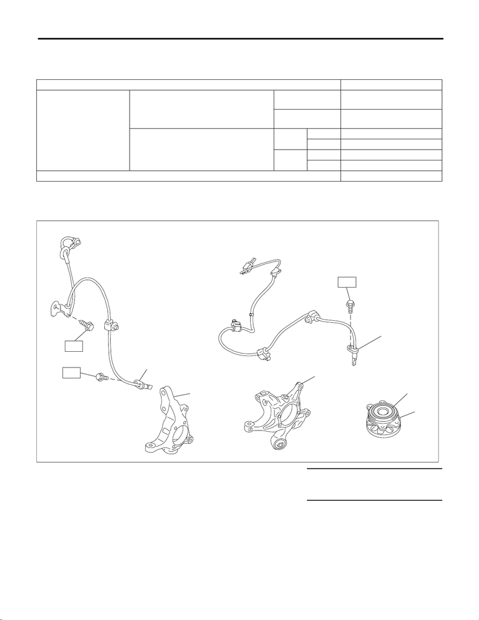

General Description

VEHICLE DYNAMICS CONTROL (VDC)

1. General Description

A: SPECIFICATION

B: COMPONENT

1. ABS WHEEL SPEED SENSOR

Item Specification or identification

ABS wheel speed sensor

ABS wheel speed sensor gap (for reference)

Front

0.77 — 1.43 mm

(0.030 — 0.056 in)

Rear

0.44 — 1.76 mm

(0.017 — 0.069 in)

Identifications of harness (symbol)

Front

RH G1

LH G2

Rear

RH G3

LH G4

VDCCM&H/U identification P1

(1) Front ABS wheel speed sensor (4) Housing ASSY - rear axle Tightening torque: N·m (kgf-m, ft-lb)

(2) Housing ASSY - front axle (5) Magnetic encoder T1: 7.5 (0.8, 5.5)

(3) Rear ABS wheel speed sensor (6) Hub unit COMPL T2: 33 (3.4, 24.3)

VDC01322

(6)

(5)

(4)

(2)

T2

T1

(1)

T1

(3)

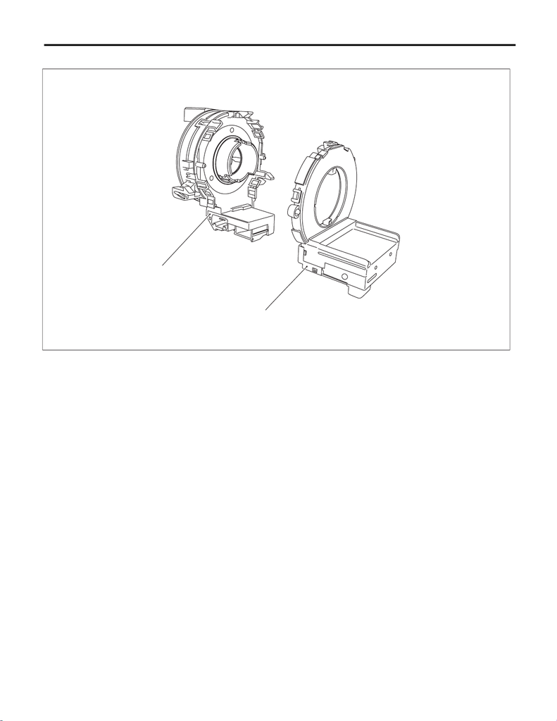

General Description

VEHICLE DYNAMICS CONTROL (VDC)

2. STEERING ANGLE SENSOR

(1) Steering roll connector (2) Steering angle sensor

VDC00986

(1)

(2)

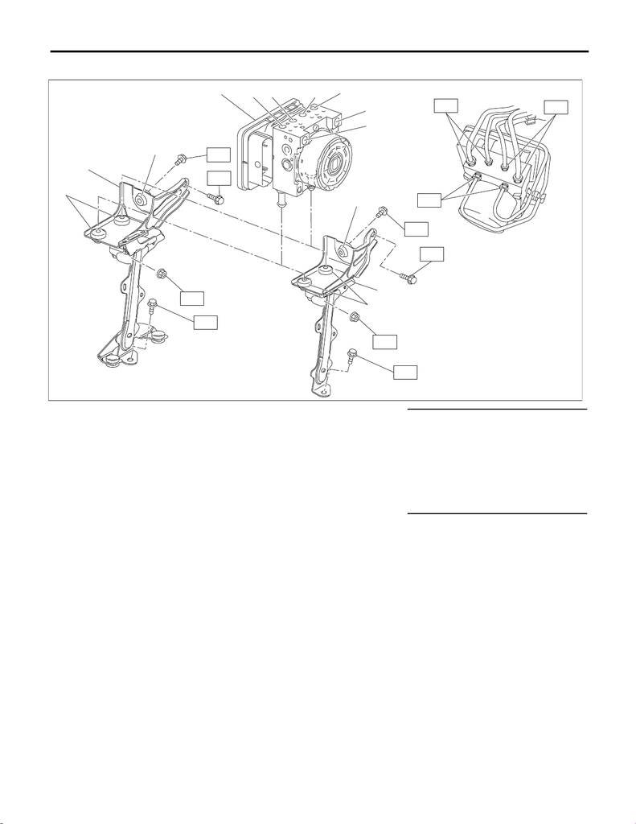

General Description

VEHICLE DYNAMICS CONTROL (VDC)

3. VDC CONTROL MODULE & HYDRAULIC CONTROL UNIT (VDCCM&H/U)

(1) VDC control module and hydraulic

control unit (VDCCM&H/U)

(7) Secondary inlet Tightening torque: N·m (kgf-m, ft-lb)

(2) Rear RH outlet (8) Damper - hydraulic unit T1: 7.5 (0.8, 5.5)

(3) Front LH outlet (9) Bracket - hydraulic unit (STI

model)

T2: 15 (1.5, 11.1)

(4) Front RH outlet (10) Spacer T3: 19 (1.9, 14.0)

(5) Rear LH outlet (11) Bracket - hydraulic unit (except for

STI model)

T4: 33 (3.4, 24.3)

(6) Primary inlet

VDC01313

T3

T2

T2

(9)

(10)

T4

T4

T1

(8)

T4

T1

(8)

T4

T4

T4

(11)

(10)

(1)

(6)

(5)

(4)

(3)

(2)

(7)

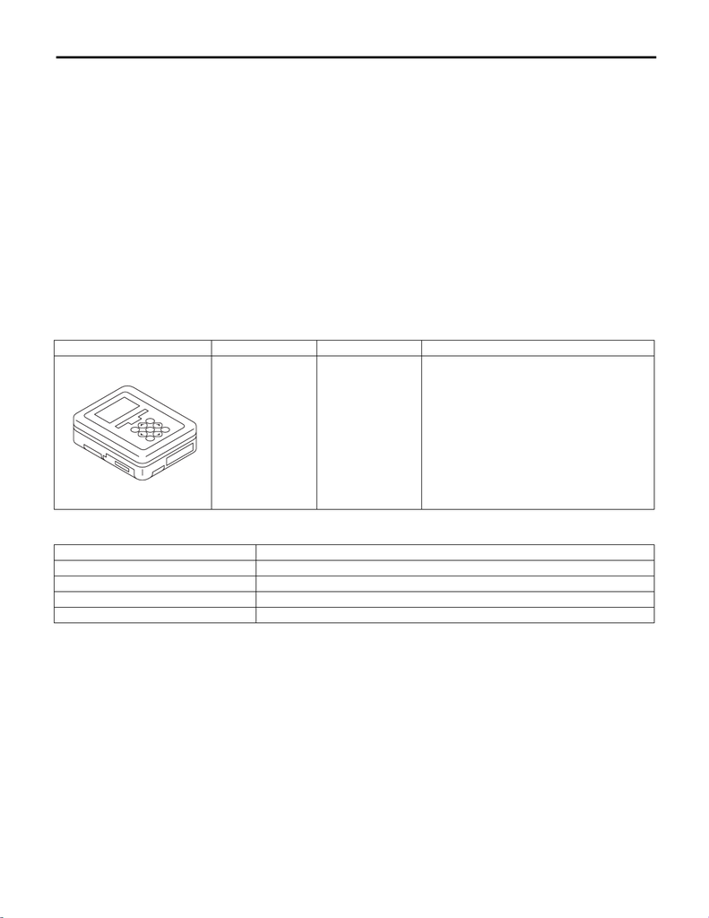

General Description

VEHICLE DYNAMICS CONTROL (VDC)

C: CAUTION

a helmet, protective goggles, etc. if necessary.

• Remove contamination including dirt and corrosion before removal, installation, disassembly or assembly.

• Keep the disassembled parts in order and protect them from dust and dirt.

• When performing a repair, identify the cause of trouble and avoid unnecessary removal, disassembly and

replacement.

• Some vehicle components are extremely hot immediately after driving. Be wary of receiving burns from

heated parts.

• Be sure to tighten fasteners including bolts and nuts to the specified torque.

• Always use the jack-up point when the shop jacks or rigid racks are used to support the vehicle.

ing angle sensor (steering roll connector), perform “VDC sensor midpoint setting mode” of the VDC. <Ref. to

VDC-16, VDC SENSOR MIDPOINT SETTING MODE, ADJUSTMENT, VDC Control Module and Hydraulic

Control Unit (VDCCM&H/U).>

D: PREPARATION TOOL

1. SPECIAL TOOL

2. GENERAL TOOL

ILLUSTRATION TOOL NUMBER DESCRIPTION REMARKS

1B022XU0 SUBARU SELECT

MONITOR III KIT

Used for setting of each function and trouble-

shooting for electrical system.

TOOL NAME REMARKS

Circuit tester Used for measuring resistance and voltage.

Pressure gauge Used for measuring oil pressure.

Oscilloscope Used for measuring the sensor.

Steering wheel puller Used for removing the steering wheel.

ST1B022XU0